# Linear Models

Question 1

```python
import pandas as pd
```

```python
import numpy as np
import seaborn as sns
import matplotlib.pyplot as plt
```

```python
file_path = 'C:/Users/angievasquez/Downloads/Q1_clean.csv'
```

```python
df = pd.read_csv('/Users/angievasquez/Downloads/Q1_clean.csv')
```

```python
df = pd.read_csv('/Users/angievasquez/Downloads/Q1_clean.csv')
```

```python
print(df.head())
```

```
   Price  Review Scores Rating Neighbourhood  Property Type        Room Type
0    549                  96.0      Manhattan     Apartment     Private room
1    149                 100.0       Brooklyn     Apartment  Entire home/apt
2    250                 100.0      Manhattan     Apartment  Entire home/apt
3     90                  94.0       Brooklyn     Apartment     Private room
4    270                  90.0      Manhattan     Apartment  Entire home/apt
```

```python
df.loc[:,['Price','Neighbourhood '] ].groupby('Neighbourhood ').describe()
```

| Neighbourhood | Price count | Price mean | Price std | Price min | Price 25% | Price 50% | Price 75% | Price max |
| --- | --- | --- | --- | --- | --- | --- | --- | --- |
| Bronx | 217.0 | 75.276498 | 39.755468 | 10.0 | 50.00 | 60.0 | 90.0 | 244.0 |
| Brooklyn | 8487.0 | 127.747378 | 106.038466 | 20.0 | 75.00 | 100.0 | 150.0 | 4500.0 |
| Manhattan | 11763.0 | 183.664286 | 170.434606 | 25.0 | 103.00 | 150.0 | 214.0 | 10000.0 |
| Queens | 1590.0 | 96.857233 | 61.712648 | 25.0 | 60.00 | 80.0 | 115.0 | 950.0 |
| Staten Island | 96.0 | 146.166667 | 508.462029 | 35.0 | 54.75 | 71.0 | 99.0 | 5000.0 |

Price count is most expensive for Manhattan and its $183/night

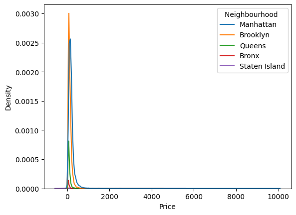

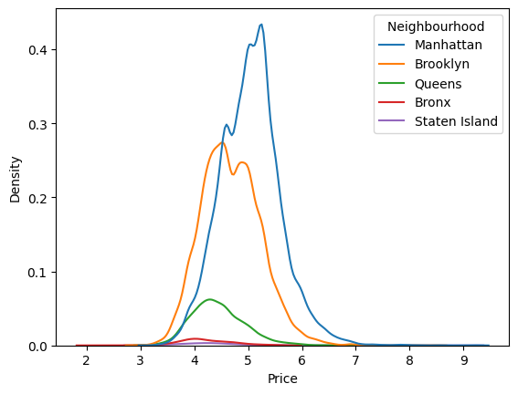

```python
sns.kdeplot(x=df['Price'], hue=df['Neighbourhood '])
plt.show()

sns.kdeplot(x=np.log(df['Price']), hue=df['Neighbourhood '])
plt.show()
```

```python
y = df['Price']
X = pd.get_dummies(df['Neighbourhood '], dtype='int')

from sklearn import linear_model
reg = linear_model.LinearRegression(fit_intercept=False).fit(X,y)

results = pd.DataFrame({'variable':reg.feature_names_in_, 'coefficient': reg.coef_})
results
```

|  | variable | coefficient |
| --- | --- | --- |
| 0 | Bronx | 75.276498 |
| 1 | Brooklyn | 127.747378 |
| 2 | Manhattan | 183.664286 |
| 3 | Queens | 96.857233 |
| 4 | Staten Island | 146.166667 |

From part 1, it matches coefficients from the regression using neighborhod dummies. Here, it calculates group averages because there aren't any additional control variables.

```python
y = df['Price']
X = pd.get_dummies(df['Neighbourhood '], dtype='int', drop_first = True)
```

```python
from sklearn import linear_model
reg = linear_model.LinearRegression().fit(X,y)

results = pd.DataFrame({'variable':reg.feature_names_in_, 'coefficient': reg.coef_})
results
```

|  | variable | coefficient |
| --- | --- | --- |
| 0 | Brooklyn | 52.470881 |
| 1 | Manhattan | 108.387789 |
| 2 | Queens | 21.580735 |
| 3 | Staten Island | 70.890169 |

```python
print(reg.intercept_)
```

```
75.27649769584711
```

```python
results = pd.DataFrame({'variable':reg.feature_names_in_,
                        'coefficient': reg.coef_+reg.intercept_})
results
```

|  | variable | coefficient |
| --- | --- | --- |
| 0 | Brooklyn | 127.747378 |
| 1 | Manhattan | 183.664286 |
| 2 | Queens | 96.857233 |
| 3 | Staten Island | 146.166667 |

The Bronx is no longer a part of it. So now it makes it the reference category and the coefficient from the regression before is represented by the intercept. Coefficients are now relative to the Bronx. adding values to the regression coefficients to the intercept can recover coefficients from previous regression.

```python
from sklearn import linear_model
from sklearn.model_selection import train_test_split

y = df['Price']
X = df.loc[:,['Review Scores Rating', 'Neighbourhood '] ]
X_train, X_test, y_train, y_test = train_test_split(X,y,
                                                    test_size=.2,
                                                    random_state=100)

Z_train = pd.concat([X_train['Review Scores Rating'],
                     pd.get_dummies(X_train['Neighbourhood '], dtype='int')], axis = 1)
Z_test = pd.concat([X_test['Review Scores Rating'],
                    pd.get_dummies(X_test['Neighbourhood '], dtype='int')], axis = 1)

reg = linear_model.LinearRegression(fit_intercept=False).fit(Z_train,y_train)
```

```python
y_hat = reg.predict(Z_test)
print('Rsq: ', reg.score(Z_test,y_test))
rmse = np.sqrt( np.mean( (y_test - y_hat)**2 ))
print('RMSE: ', rmse)
```

```
Rsq:  0.06701086106947252
RMSE:  125.01092061382934
```

```python
results = pd.DataFrame({'variable':reg.feature_names_in_, 'coefficient': reg.coef_}) # Regression coefficients
results
```

|  | variable | coefficient |
| --- | --- | --- |
| 0 | Review Scores Rating | 1.032257 |
| 1 | Bronx | -17.261392 |
| 2 | Brooklyn | 32.180888 |
| 3 | Manhattan | 89.421020 |
| 4 | Queens | 4.050208 |
| 5 | Staten Island | 61.576393 |

```python
100*1.032257 + 89.4
```

```
192.6257
```

Expensive property to rent is in Manhattan for approximately $192/night

```python
y = df['Price']
X = df.loc[:,['Review Scores Rating', 'Neighbourhood ', 'Room Type'] ]
X_train, X_test, y_train, y_test = train_test_split(X,y,
                                                    test_size=.2,
                                                    random_state=100)

Z_train = pd.concat([X_train['Review Scores Rating'],
                    pd.get_dummies(X_train['Neighbourhood '], dtype='int'),
                    pd.get_dummies(X_train['Room Type'], dtype='int')],
                    axis = 1)
Z_test = pd.concat([X_test['Review Scores Rating'],
                    pd.get_dummies(X_test['Neighbourhood '], dtype='int'),
                    pd.get_dummies(X_test['Room Type'], dtype='int')],
                    axis = 1)
reg = linear_model.LinearRegression(fit_intercept=False).fit(Z_train,y_train)
y_hat = reg.predict(Z_test)
print('Rsq: ', reg.score(Z_test,y_test)) # R2
rmse = np.sqrt( np.mean( (y_test - y_hat)**2 ))
print('RMSE: ', rmse) # R2
results = pd.DataFrame({'variable':reg.feature_names_in_, 'coefficient': reg.coef_})
results
```

```
Rsq:  0.2203534812928234
RMSE:  114.27692123130632
```

|  | variable | coefficient |
| --- | --- | --- |
| 0 | Review Scores Rating | 0.626912 |
| 1 | Bronx | -13.022765 |
| 2 | Brooklyn | 10.378456 |
| 3 | Manhattan | 53.693304 |
| 4 | Queens | -6.833330 |
| 5 | Staten Island | 50.003022 |
| 6 | Entire home/apt | 110.617820 |
| 7 | Private room | 3.101341 |
| 8 | Shared room | -19.500474 |

```python
110.617+53.69+100*.0626
```

```
170.567
```

Change in coefficient from 1.03 to 0.63 reflects the effects of including room type. Since it first didn't account for this, the influence of ratings on prices was stronger. In part 5 when room type was added as a variable, there was variation in prices based on the rating. This can mean that once there is control for room type, other variables including rating lose some of their predictive power since it was previously tied to room type, which is why the coefficient fro the rating decreases.

Question 2

```python
import pandas as pd
```

```python
import numpy as np
```

```python
import seaborn as sns
```

```python
file_path = 'C:/Users/angievasquez/Downloads/cars_hw.csv'
```

```python
df = pd.read_csv('/Users/angievasquez/Downloads/cars_hw.csv')
```

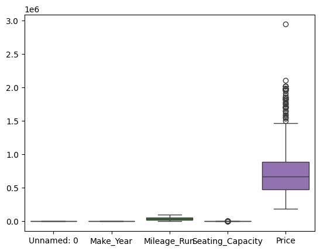

```python
df0 = df
sns.boxplot(data=df)
```

```python
print(df.columns)
```

```
Index(['Unnamed: 0', 'Make', 'Make_Year', 'Color', 'Body_Type', 'Mileage_Run',
       'No_of_Owners', 'Seating_Capacity', 'Fuel_Type', 'Transmission',
       'Transmission_Type', 'Price'],
      dtype='object')
```

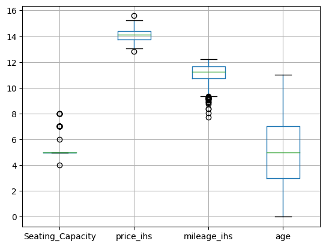

```python
df['price_ihs'] = np.arcsinh(df['Price'])
df['mileage_ihs'] = np.arcsinh(df['Mileage_Run'])
df['age'] = max(df['Make_Year'])-df['Make_Year']
df = df.drop(['Price','Mileage_Run','Make_Year','Unnamed: 0'],axis=1)
df.boxplot()
```

[output not shown]

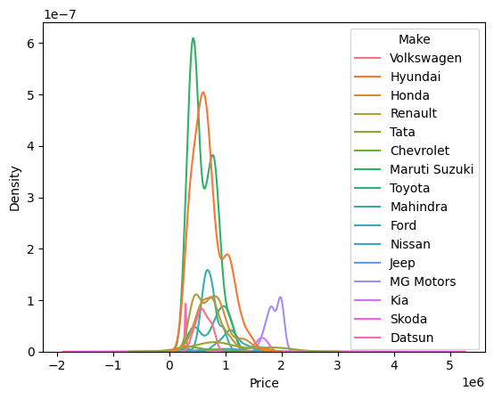

```python
sns.kdeplot(data = df0, x='Price',hue='Make')
df0['Price'].groupby(df0['Make']).describe()
```

[output not shown]

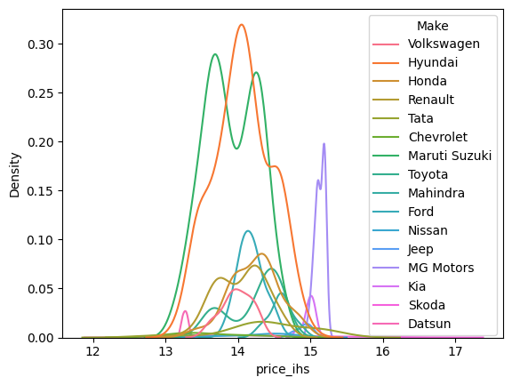

```python
sns.kdeplot(data=df,x='price_ihs',hue='Make')
df['price_ihs'].groupby(df['Make']).describe()
```

[output not shown]

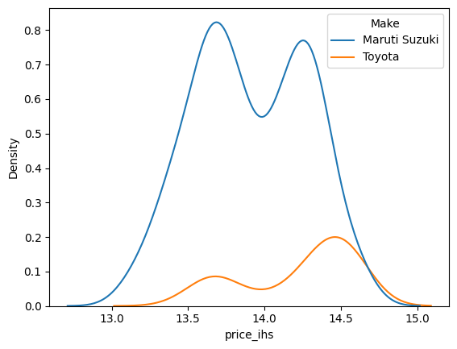

```python
sns.kdeplot(data=df.loc[ df['Make'].isin(['Maruti Suzuki','Toyota'])  ,:],x='price_ihs',hue='Make')
```

Density plot shows that prices are single peaked (with exception of Toyota and Maruti Suzuki) also shows that MG Motors are the most expensive, followed by Kia and Jeep.

```python
N = df.shape[0]
df = df.sample(frac=1, random_state=100)
train_size = int(.8*N)

df_train = df[0:train_size]
y_train = df_train['price_ihs']

df_test = df[train_size:]
y_test = df_test['price_ihs']
```

```python
from sklearn import linear_model
```

```python
numeric_features = ['Seating_Capacity', 'age']
X_train_numeric = df_train[numeric_features]
X_test_numeric = df_test[numeric_features]
```

```python
var_n = ['age','mileage_ihs','Seating_Capacity']
X_train_n = df_train.loc[:,var_n]
reg_n = linear_model.LinearRegression().fit(X_train_n,y_train)
X_test_n = df_test.loc[:,var_n]
y_hat = reg_n.predict(X_test_n)
print('Numeric only Rsq: ', reg_n.score(X_test_n,y_test))
rmse_n = np.sqrt( np.mean( (y_test - y_hat)**2 ))
print('Numeric only RMSE: ', rmse_n)
```

```
Numeric only Rsq:  0.45254262356326813
Numeric only RMSE:  0.3339265473590647
```

```python
var_cat = ['Make','Body_Type','Color','Fuel_Type','Transmission','Transmission_Type']


dummies = pd.DataFrame([])
for var in var_cat:
    new_dummies = pd.get_dummies( df.loc[:,var], drop_first=True, dtype=int)
    dummies = pd.concat([dummies, new_dummies], axis=1, ignore_index=True)
    X_train_c = dummies.iloc[0:train_size,:]
    X_test_c = dummies.iloc[train_size:,:]

reg_c = linear_model.LinearRegression().fit(X_train_c,y_train)
y_hat_c = reg_c.predict(X_test_c)
print('Categorical only Rsq: ', reg_c.score(X_test_c,y_test))
rmse_c = np.sqrt( np.mean( (y_test - y_hat_c)**2 ))
print('Categorical only RMSE: ', rmse_c)
```

```
Categorical only Rsq:  0.6298129532407475
Categorical only RMSE:  0.27459106425227237
```

```python
X_train_all = pd.concat([X_train_n, X_train_c],axis=1, ignore_index=True)
X_test_all = pd.concat([X_test_n, X_test_c],axis=1, ignore_index=True)

reg_all = linear_model.LinearRegression().fit(X_train_all,y_train)
y_hat_all = reg_all.predict(X_test_all)
print('All Rsq: ', reg_all.score(X_test_all,y_test))
rmse_all = np.sqrt( np.mean( (y_test - y_hat_all)**2 ))
print('All RMSE: ', rmse_all)
```

```
All Rsq:  0.7999206763763923
All RMSE:  0.20187237686198908
```

```python
from sklearn.preprocessing import PolynomialFeatures
```

```python
for d in np.arange(1,5):
    expander = PolynomialFeatures(degree=d,include_bias=False)


    Z = expander.fit_transform(X_test_n)
    names = expander.get_feature_names_out()
    X_test_d = pd.DataFrame(data=Z, columns = names)
    Z = expander.fit_transform(X_train_n)
    names = expander.get_feature_names_out()
    X_train_d = pd.DataFrame(data=Z, columns = names)
    X_train_d.reset_index(drop=True, inplace=True)
    X_train_c.reset_index(drop=True, inplace=True)
    X_train_all = pd.concat([X_train_d, X_train_c], axis=1, ignore_index=True)


    X_test_d.reset_index(drop=True, inplace=True)
    X_test_c.reset_index(drop=True, inplace=True)
    X_test_all = pd.concat([X_test_d, X_test_c], axis=1, ignore_index=True)


    reg_all = linear_model.LinearRegression().fit(X_train_all,y_train)
    print(d, ' Rsq: ', reg_all.score(X_test_all,y_test))
    y_hat_all = reg_all.predict(X_test_all)
    rmse_all = np.sqrt( np.mean( (y_test - y_hat_all)**2 ))
    print(d, 'RMSE: ', rmse_all)
```

```
1  Rsq:  0.7999206763763923
1 RMSE:  0.20187237686198908
2  Rsq:  0.8025408094604647
2 RMSE:  0.20054621389085725
3  Rsq:  0.7996599800455597
3 RMSE:  0.20200385035770388
4  Rsq:  -37443641390.934616
4 RMSE:  87330.27541457406
```

Best degree is 2

```python
d = 2

expander = PolynomialFeatures(degree=d,include_bias=False)
Z = expander.fit_transform(X_test_n)
names = expander.get_feature_names_out()
X_test_d = pd.DataFrame(data=Z, columns = names)

Z = expander.fit_transform(X_train_n)
names = expander.get_feature_names_out()
X_train_d = pd.DataFrame(data=Z, columns = names)

X_train_d.reset_index(drop=True, inplace=True)
X_train_c.reset_index(drop=True, inplace=True)
X_train_all = pd.concat([X_train_d, X_train_c], axis=1)
X_train_all.columns = X_train_all.columns.astype(str)
X_test_d.reset_index(drop=True, inplace=True)
X_test_c.reset_index(drop=True, inplace=True)
X_test_all = pd.concat([X_test_d, X_test_c], axis=1)
X_test_all.columns = X_test_all.columns.astype(str)
```

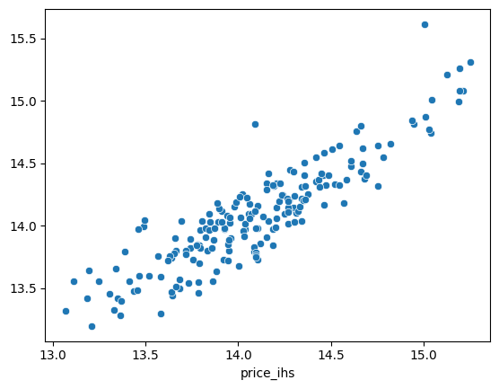

```python
reg_all = linear_model.LinearRegression().fit(X_train_all,y_train)

y_hat_all = reg_all.predict(X_test_all)
residuals = y_test - y_hat_all


sns.scatterplot(x=y_test,y=y_hat_all)
```

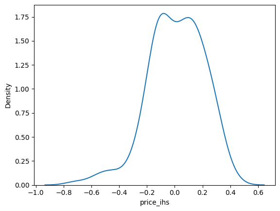

```python
sns.kdeplot(residuals)
```

Seems to have a left tail but for mostly looks to be symmetrical and bell shaped.

This bi-modal pattern can mean that there's more underlying and unobserved variations in the data can adds to the multiple peaks.